# 🏥 Analyzing **Health** and **Poverty** Data Across US Counties (2022)

## 🅿️1️⃣ Part 1 - Data Description & Manipulation

## 👥 Team Members

- **[Shreya Gupta]** (*gshrey*)
- **[Vaishnavi Venkataraghavan]** (*vaishven*)
- **[James Gair]** (*jgair*)

## 📝 Overview

This project examines **health-related statistics** and **poverty levels** across Michigan counties using **public datasets** from *CDC PLACES* and *U.S. Census Bureau's American Community Survey*. The goal is to uncover patterns in:

- **Health outcomes** 🏥
- **Disabilities** ♿
- **Risk behaviors** 🚬🏃‍♂️
- **Socioeconomic factors** 💰

By analyzing these factors, we aim to **identify disparities** and **understand trends** across different regions.

## 💡 Motivation

Health and economic conditions are deeply **intertwined**, influencing access to healthcare, disease prevalence, and overall well-being. By analyzing these datasets, we aim to explore **how poverty correlates** with various health indicators at the county level.

### 🔍 *Real-World Questions*

1. **How does the relationship between poverty rates and disease prevalence vary across U.S. counties, and do high-poverty areas experience significantly worse health outcomes compared to wealthier counties?**
2. **What health risk behaviors are most prevalent in counties with higher poverty rates, and how do these behaviors correlate with disease prevalence?**
3. **How do rural and urban counties differ in the impact of income on disease prevalence, and what specific diseases are most prevalent in these counties?**

## 📊 Data Sources

### 🏥 1. **CDC PLACES Health Data**

- **URL:** [CDC PLACES](https://data.cdc.gov/500-Cities-Places/PLACES-Local-Data-for-Better-Health-County-Data-20/swc5-untb/about_data)
- *This dataset provides county-level health indicators, including disability prevalence, chronic conditions, and health-related behaviors.*

### 📈 2. **U.S. Census Bureau ACS 5-Year Estimates (Poverty and Median Income Data)**

- **URL:** [Census ACS API](https://www.census.gov/data/developers/data-sets.html)
- *This api includes socioeconomic data such as poverty rates and income levels across different counties.*

### 🎯 *How These Datasets Complement Each Other*

The **CDC dataset** provides detailed *health-related statistics*, while the **Census American Community Survey dataset** offers *economic indicators* such as poverty rates and household incomes. By combining them, we can analyze **correlations** between economic status and health outcomes, helping us **identify trends and disparities** across Michigan counties.

## 📊 Data Description

Our project focuses on the following **key variables**:

### 📌 *CDC Places Health Dataset Variables (2022)*

Although the current release of PLACES was published in 2024, it contains Behavioral Risk Factor Surveillance System (BRFSS) data from 2022/ 2021 against Census 5 year estimates.

- **Year** – The year of data collection (e.g., 2022 (2021 for certain measures))
- **StateAbbr** – Abbreviation of the state (e.g., FL for Florida)
- **StateDesc** – Full name of the state
- **LocationName** – County name
- **Category** – Type of health indicator (e.g., Health Outcomes)
- **Measure** – Detailed description of the health measure (e.g., "Arthritis among adults")
- **Data_Value_Unit** – Unit of measurement (percentage in this case)
- **Data_Value_Type** – Type of value, consists of crude and age-adjusted prevalence, but we're only taking age-adjusted prevalence
- **Data_Value** – Percentage of the county population affected
- **TotalPopulation** – Total population of the county
- **TotalPop18plus** – Population of adults aged 18 and older
- **LocationID** – Unique identifier for the location
- **CategoryID** – Code representing the health indicator category
- **MeasureId** – Code representing the specific health measure
- **Short_Question_Text** – Short name of the health measure (e.g., "Obesity", "Stroke")

### 📌 *Census ACS 5-Year Poverty Dataset Variables (2022)*

- **Geography** – Unique geographic identifier *[GEO_ID]*
- **Geographic Area Name** – Name of the geographic area *[NAME]*
- **Total** – Total population *[S1701_C01_001E]*
- **T_ Male** – Total male population *[S1701_C01_011E]*
- **T_ Female** – Total female population *[S1701_C01_012E]*
- **T_ African American** – Total African American population *[S1701_C01_014E]*
- **T_ American Indian/Alaska Native** – Total American Indian/Alaska Native population *[S1701_C01_015E]*
- **T_ Asian** – Total Asian population *[S1701_C01_016E]*
- **T_ Hawaiian/ Pacific Islander** – Total Hawaiian/Pacific Islander population *[S1701_C01_017E]*
- **T_ Two or more races** – Total population of two or more races *[S1701_C01_019E]*
- **T_ Other race** – Total population of other races *[S1701_C01_018E]*
- **T_ Hispanic or Latino** – Total Hispanic or Latino population *[S1701_C01_020E]*
- **T_ White** – Total White population *[S1701_C01_021E]*
- **BP_ Male** – Below poverty male population *[S1701_C02_011E]*
- **BP_ Female** – Below poverty female population *[S1701_C02_012E]*
- **BP_ African American** – Below poverty African American population *[S1701_C02_014E]*
- **BP_ American Indian/Alaska Native** – Below poverty American Indian/Alaska Native population *[S1701_C02_015E]*
- **BP_ Asian** – Below poverty Asian population *[S1701_C02_016E]*
- **BP_ Hawaiian/ Pacific Islander** – Below poverty Hawaiian/Pacific Islander population *[S1701_C02_017E]*
- **BP_ Two or more races** – Below poverty population of two or more races *[S1701_C02_019E]*
- **BP_ Other race** – Below poverty population of other races *[S1701_C02_018E]*
- **BP_ Hispanic or Latino** – Below poverty Hispanic or Latino population *[S1701_C02_020E]*
- **BP_ White** – Below poverty White population *[S1701_C02_021E]*
- **BP_ Total%** – Below poverty White population *[S1701_C02_021E]*
- **T_Households** – Total number of households *[S1901_C01_001E]*
- **Households<$10k** – Number of households earning less than $10,000 *[S1901_C01_002E]*
- **Households>$200k** – Number of households earning more than $200,000 *[S1901_C01_011E]*
- **Median income** – Median household income *[S1901_C01_012E]*
- **Mean income** – Mean (average) household income *[S1901_C01_013E]*

### 📊 *Dataset Size & Structure*

[output not shown]

### ⚠️ *Handling Missing Data*

- *CDC PLACES Health Data:* There are no missing values in this dataset.
- *ACS Census Data:* Some counties have `-999999999` or `-888888888` values, which are replaced with `0` for analysis.

## 🎨 Visualization Plan

We will generate:

- **Bar Charts** 📊 to visualize *health disparities by county*
- **Stacked Bar Charts** 📊 to compare *disability rates across top 5 counties*
- **Histogram and Box Plots** 📊 to examine *median incomes across counties*

By the end of this project, we hope to uncover **key insights** that can aid in **policy-making** and **resource allocation** for public health improvement in Michigan. 🚀

## ⚙️ Initial Setup for Analyzing the CDC PLACES Dataset

To begin analyzing the **CDC PLACES health data**, we will first set up the necessary environment and import the required libraries.

### Libraries Used

We will use the following libraries in this part of the project:

- **Pandas** 📑:
  - Pandas is a library for handling and analyzing structured data especially when it is in DataFrame format.
  - We will use it for loading the dataset, cleaning data, filtering rows, and aggregating statistics.
- **Matplotlib** (`matplotlib.pyplot`) 📊 :
  - Matplotlib is a visualization library that allows us to create static or animated interactive plots and graphs.
  - It will be used to generate charts and plots.
- **Seaborn** 🎨:
  - Seaborn is a data visualization library built on top of Matplotlib and it provides a high-level interface for drawing attractive and informative statistical graphics.
  - We will use it for creating visually appealing plots.
- **Requests** 🌐:
  - Requests is a library for making HTTP requests to interact with web resources.
  - We will use it to fetch data from the Census ACS API.
- **NumPy** 🔢:
  - NumPy is a fundamental library for numerical computing in Python, providing support for arrays, matrices, and a collection of mathematical functions.
  - We will use it for some numerical operations.

### 🔧 Setting Up the Environment

Before diving into the analysis, let's ensure that we have all the libraries installed and imported correctly.

### 📂 Loading the Data

We will also load the **CDC PLACES dataset**. The dataset will be loaded into a Pandas DataFrame, which will allow us to easily manipulate and analyze the data.

```python
# Import necessary libraries
import pandas as pd
import matplotlib.pyplot as plt
import seaborn as sns
import requests
import numpy as np
```

To start off, we are going to to suppress `FutureWarnings`, which are messages about potential changes in future versions of Pandas or other libraries. This helps keep the output clean while running the script.

```python
# Import the warnings module
import warnings
warnings.simplefilter(action='ignore', category=FutureWarning)
```

```python
import os

try:
    current_dir = os.path.dirname(__file__)
except NameError:
    current_dir = os.getcwd()
data_dir = os.path.join(current_dir, "data")
```

To improve the readability of the data, we will also ensure that all floating-point numbers displayed in Pandas DataFrames are formatted to two decimal places. This will make the output more concise and easier to interpret. Additionally, this will also avoid scientific notations throughout the notebook.

```python
# Set Pandas display options to format floating-point numbers with 2 decimal places
pd.options.display.float_format = '{:.2f}'.format
```

Let's load the dataset into a Pandas DataFrame. Then we will display the first five rows of the dataset so that we can inspect its structure.

```python
# Read the csv file
health_df = pd.read_csv(os.path.join(data_dir, "PLACES.csv"))
health_df.head()
```

|  | Year | StateAbbr | StateDesc | LocationName | Category | Measure | Data_Value_Unit | Data_Value_Type | Data_Value | TotalPopulation | TotalPop18plus | LocationID | CategoryID | MeasureId | Short_Question_Text |
| --- | --- | --- | --- | --- | --- | --- | --- | --- | --- | --- | --- | --- | --- | --- | --- |
| 0 | 2022 | FL | Florida | Alachua | Health Outcomes | Arthritis among adults | % | Age-adjusted prevalence | 24.40 | 284030 | 234132 | 12001 | HLTHOUT | ARTHRITIS | Arthritis |
| 1 | 2022 | GA | Georgia | Burke | Health Outcomes | Stroke among adults | % | Age-adjusted prevalence | 4.20 | 24388 | 18410 | 13033 | HLTHOUT | STROKE | Stroke |
| 2 | 2022 | GA | Georgia | Lowndes | Health Outcomes | Stroke among adults | % | Age-adjusted prevalence | 4.10 | 119739 | 90624 | 13185 | HLTHOUT | STROKE | Stroke |
| 3 | 2022 | GA | Georgia | Macon | Health Outcomes | Arthritis among adults | % | Age-adjusted prevalence | 30.00 | 11765 | 9604 | 13193 | HLTHOUT | ARTHRITIS | Arthritis |
| 4 | 2022 | GA | Georgia | Pulaski | Health Outcomes | Stroke among adults | % | Age-adjusted prevalence | 4.10 | 9984 | 8248 | 13235 | HLTHOUT | STROKE | Stroke |

The dataset provides both state-wise and county-wise data. The `Data_Value_Type` consists of Age-adjusted prevalence alone, while the initial dataset had both Age-adjusted and Crude prevalence.

As [Missouri Department of Health and Senior Services](https://health.mo.gov/data/documentation/crude-aarate.php#:~:text=Age%20adjusting%20rates%20allows%20fairer%20comparisons,the%20different%20geographies%20more%20comparable.) states:

*Age adjusting rates allows fairer comparisons to be made between groups with different age distributions. For example, a county with a high percentage of elderly residents may have a higher rate of death or hospitalization than a county with a younger population, merely because the elderly are more likely to die or be hospitalized. (The same distortion can happen when comparing races, genders, or time periods.) Age adjustment can make the different geographies more comparable.*

Therefore, we have decided to use Age-adjusted data. Immediately, `Data_Value`, `Total_Population`, `Category`, `LocationName` (County), and `Measure` immediately stand out for data visualization.

Now, we need to check the data types of each column in the DataFrame. It will help us determine how to clean and manipulate the data (e.g., do we need to convert categorical data for analysis? Are there potential mismatches?) This step will ensures correct data type conversions before performing calculations or merging with our second dataset.

```python
health_df.dtypes #Check the data types
```

```
Year                     int64
StateAbbr               object
StateDesc               object
LocationName            object
Category                object
Measure                 object
Data_Value_Unit         object
Data_Value_Type         object
Data_Value             float64
TotalPopulation          int64
TotalPop18plus           int64
LocationID               int64
CategoryID              object
MeasureId               object
Short_Question_Text     object
dtype: object
```

```python
health_df["LocationID"] = health_df["LocationID"].astype("object")
```

Next, we will generate a summary statistics for all numerical columns in the DataFrame. The output should include metrics such as count, mean, standard deviation, minimum, maximum, and quartiles (25%, 50% (Median), 75%) for each numerical column.

```python
health_df.describe()
```

|  | Year | Data_Value | TotalPopulation | TotalPop18plus |
| --- | --- | --- | --- | --- |
| count | 120443.00 | 120443.00 | 120443.00 | 120443.00 |
| mean | 2021.90 | 25.12 | 216290.74 | 169223.65 |
| std | 0.30 | 20.93 | 6079990.58 | 4758332.31 |
| min | 2021.00 | 1.70 | 51.00 | 37.00 |
| 25% | 2022.00 | 9.50 | 10769.00 | 8398.00 |
| 50% | 2022.00 | 18.00 | 25940.00 | 20459.00 |
| 75% | 2022.00 | 32.70 | 68826.00 | 53686.00 |
| max | 2022.00 | 89.70 | 333287557.00 | 260836730.00 |

We can infer the following after summarizing the data:

- **Percent per Population (Data_Value)**:
  - The **standard deviation** is high at **20.93**, so we know there is substantial variation in health conditions across locations.
- **Population Size**:
  - The population size per location varies significantly, ranging from small counties with about **50 residents** to country-wide population.
  - The **mean** and **median population size** vary significantly.
- **Need for Granularization**:
  - The reason for this variation in data is also because there are few rows in the dataset that gives country level statistics, which consists of the population of the entirety of US.
  - Therefore, it would help to have a **granular** view of the data. Perhaps, for the state of **Michigan**?

### Data Processing

Since the `Data_Value`, which shows us the percentage of individuals affected by a particular health condition, is in percentage format, we need to obtain the actual number of people affected for our analysis. To do this, we create two new columns where values are stored as integers:

These new columns will allow us to work with counts of people, making our analysis easier to understand and enabling better comparisons across different locations and group types.

```python
# Calculate the total number of patients based on the Data_Value and TotalPopulation
health_df['TotalPatients'] = (
    health_df['Data_Value'] * health_df['TotalPopulation'] / 100
).astype('int64')  # Convert the result to 'int64' type

# Calculate the total number of patients aged 18 and above based on the Data_Value and TotalPop18plus
health_df['TotalPatients18plus'] = (
    health_df['Data_Value'] * health_df['TotalPop18plus'] / 100
).astype('int64')  # Convert the result to 'int64' type
```

Next, to take a more granular look, let's filter the data to focus specifically on Michigan state, and within that, we'll generate a `head()` view on **Wayne County** to see if our new metrics are appearing as expected.

```python
# Filter the DataFrame to include only rows where the 'StateAbbr' is 'MI' (Michigan)
michigan_df = health_df[health_df['StateAbbr'] == 'MI']

# Further filter the DataFrame to include only rows where the 'LocationName' is 'Wayne'
# and display the first 5 rows of the resulting DataFrame
michigan_df[michigan_df['LocationName'] == 'Wayne'].head()
```

|  | Year | StateAbbr | StateDesc | LocationName | Category | Measure | Data_Value_Unit | Data_Value_Type | Data_Value | TotalPopulation | TotalPop18plus | LocationID | CategoryID | MeasureId | Short_Question_Text | TotalPatients | TotalPatients18plus |
| --- | --- | --- | --- | --- | --- | --- | --- | --- | --- | --- | --- | --- | --- | --- | --- | --- | --- |
| 45177 | 2022 | MI | Michigan | Wayne | Prevention | Current lack of health insurance among adults ... | % | Age-adjusted prevalence | 8.10 | 1757043 | 1345110 | 26163 | PREVENT | ACCESS2 | Health Insurance | 142320 | 108953 |
| 45266 | 2022 | MI | Michigan | Wayne | Health-Related Social Needs | Feeling socially isolated among adults | % | Age-adjusted prevalence | 33.20 | 1757043 | 1345110 | 26163 | SOCLNEED | ISOLATION | Social Isolation | 583338 | 446576 |
| 45353 | 2022 | MI | Michigan | Wayne | Health Outcomes | Diagnosed diabetes among adults | % | Age-adjusted prevalence | 11.60 | 1757043 | 1345110 | 26163 | HLTHOUT | DIABETES | Diabetes | 203816 | 156032 |
| 45439 | 2022 | MI | Michigan | Wayne | Health Outcomes | Cancer (non-skin) or melanoma among adults | % | Age-adjusted prevalence | 6.40 | 1757043 | 1345110 | 26163 | HLTHOUT | CANCER | Cancer (non-skin) or Melanoma | 112450 | 86087 |
| 45458 | 2022 | MI | Michigan | Wayne | Health Outcomes | Obesity among adults | % | Age-adjusted prevalence | 36.70 | 1757043 | 1345110 | 26163 | HLTHOUT | OBESITY | Obesity | 644834 | 493655 |

As expected, the **TotalPatients** and **TotalPatients18plus** columns come through, providing the estimated number of individuals affected by the corresponding health measures. Let's use the `describe()` function again to see if variance in central tendencies have gotten any better.

```python
michigan_df.describe()
```

|  | Year | Data_Value | TotalPopulation | TotalPop18plus | TotalPatients | TotalPatients18plus |
| --- | --- | --- | --- | --- | --- | --- |
| count | 3320.00 | 3320.00 | 3320.00 | 3320.00 | 3320.00 | 3320.00 |
| mean | 2021.90 | 24.43 | 120892.93 | 95474.92 | 29389.61 | 23196.83 |
| std | 0.30 | 21.57 | 259619.78 | 202316.84 | 89932.35 | 70121.13 |
| min | 2021.00 | 2.20 | 2180.00 | 1834.00 | 54.00 | 45.00 |
| 25% | 2022.00 | 8.90 | 22870.00 | 18122.00 | 2751.75 | 2253.75 |
| 50% | 2022.00 | 16.30 | 37035.00 | 29813.00 | 7190.50 | 5820.00 |
| 75% | 2022.00 | 31.10 | 98567.00 | 78539.00 | 20264.25 | 16121.50 |
| max | 2022.00 | 87.90 | 1757043.00 | 1345110.00 | 1488215.00 | 1139308.00 |

**For the state of Michigan,**

- **Data_Value**: The mean value is 24.43%, but it has a high standard deviation (21.57), indicating substantial variation across locations and health measures.
- **TotalPopulation**: The average population size per location is about 120,893, with a standard deviation of 259,619. This high standard deviation reflects the large variation in population sizes across different locations. Some locations have populations as low as 2,180, while the largest has 1,757,043 people.
- **TotalPop18plus**: Similarly, the adult population (18 years and older) averages 95,475, with a standard deviation of 202,317.
- **TotalPatients**: The estimated total number of people affected by the condition in the entire population across all locations has a mean of 29,389.61, but with high variation, as shown by the standard deviation of 89,932.35. This is further emphasized by the range between 54 and 1,488,215 affected individuals.
- **TotalPatients18plus**: This column shows the number of individuals aged 18 and older affected by the condition. The mean is 23,196.83, and the standard deviation is 70,121.13, reflecting the significant disparity across locations. The values range from 45 to over 1 million individuals.

In summary, although the substantial variation is somewhat reduced against looking at the entire dataset, there is still significant variance between counties since they differ in population and prevalence of health measures in patients.

To further explore the Dataset, let's look at the unique values in the "Category" column.

```python
michigan_df['Category'].unique()
```

```
array(['Health Outcomes', 'Disability', 'Health Status', 'Prevention',
       'Health-Related Social Needs', 'Health Risk Behaviors'],
      dtype=object)
```

The unique categories include 'Health Outcomes', 'Disability', 'Health Status', 'Prevention', 'Health-Related Social Needs', 'Health Risk Behaviors'. These categories represent different health conditions or factors being tracked in the dataset across various locations in Michigan.

By examining these unique values, we can determine the variety of health issues the dataset covers and decide which categories are most relevant for further analysis.

Next, for more targeted analysis, we are going to display the unique combinations of the "Measure" and "Short_Question_Text" columns in the dataset. This can help us identify all the distinct measures and their corresponding questions related to health conditions that are included in the data.

```python
# Drop duplicate rows
michigan_df[['Measure', 'Short_Question_Text']].drop_duplicates()
```

|  | Measure | Short_Question_Text |
| --- | --- | --- |
| 19 | Stroke among adults | Stroke |
| 20 | Obesity among adults | Obesity |
| 45052 | Cognitive disability among adults | Cognitive Disability |
| 45056 | Vision disability among adults | Vision Disability |
| 45057 | Self-care disability among adults | Self-care Disability |
| 45058 | Diagnosed diabetes among adults | Diabetes |
| 45060 | Mobility disability among adults | Mobility Disability |
| 45064 | Independent living disability among adults | Independent Living Disability |
| 45067 | Fair or poor self-rated health status among ad... | General Health |
| 45068 | Frequent mental distress among adults | Frequent Mental Distress |
| 45070 | Mammography use among women aged 50-74 years | Mammography |
| 45071 | High blood pressure among adults | High Blood Pressure |
| 45075 | Coronary heart disease among adults | Coronary Heart Disease |
| 45076 | Cholesterol screening among adults | Cholesterol Screening |
| 45078 | Frequent physical distress among adults | Frequent Physical Distress |
| 45091 | Arthritis among adults | Arthritis |
| 45094 | Received food stamps in the past 12 months amo... | Food Stamps |
| 45100 | Visits to doctor for routine checkup within th... | Annual Checkup |
| 45105 | Short sleep duration among adults | Short Sleep Duration |
| 45114 | High cholesterol among adults who have ever be... | High Cholesterol |
| 45117 | Taking medicine to control high blood pressure... | High Blood Pressure Medication |
| 45127 | Current cigarette smoking among adults | Current Cigarette Smoking |
| 45137 | Utility services shut-off threat in the past 1... | Utility Services Threat |
| 45143 | Cancer (non-skin) or melanoma among adults | Cancer (non-skin) or Melanoma |
| 45153 | Colorectal cancer screening among adults aged ... | Colorectal Cancer Screening |
| 45155 | Hearing disability among adults | Hearing Disability |
| 45160 | All teeth lost among adults aged >=65 years | All Teeth Lost |
| 45177 | Current lack of health insurance among adults ... | Health Insurance |
| 45182 | Feeling socially isolated among adults | Social Isolation |
| 45222 | Chronic obstructive pulmonary disease among ad... | COPD |
| 45228 | Visited dentist or dental clinic in the past y... | Dental Visit |
| 45238 | Binge drinking among adults | Binge Drinking |
| 45258 | Lack of reliable transportation in the past 12... | Transportation Barriers |
| 45265 | Housing insecurity in the past 12 months among... | Housing Insecurity |
| 45308 | Lack of social and emotional support among adults | Lack of Social/Emotional Support |
| 45331 | Depression among adults | Depression |
| 45354 | Food insecurity in the past 12 months among ad... | Food Insecurity |
| 45355 | No leisure-time physical activity among adults | Physical Inactivity |
| 45445 | Any disability among adults | Any Disability |
| 45447 | Current asthma among adults | Current Asthma |

These measures cover a wide range of health conditions, behaviors, and social factors, with a focus on various disabilities, chronic conditions, and social determinants of health such as access to care, social isolation, and food insecurity.

### Data Visualization

In this section, we'll create a **2x3 subplot grid** to visualize the total number of people affected by different health categories in Michigan. The categories are as follows:

- **Health Outcomes**
- **Disability**
- **Health Status**
- **Prevention**
- **Health-Related Social Needs**
- **Health Risk Behaviors**

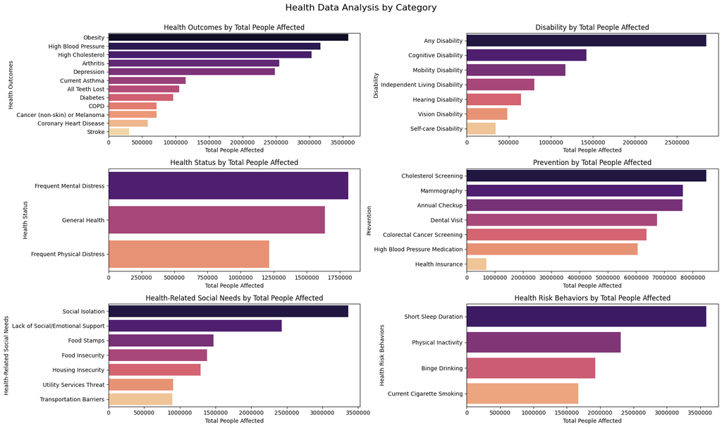

```python
# Define the list of categories to filter the data by
categories = ['Health Outcomes', 'Disability', 'Health Status', 'Prevention', 'Health-Related Social Needs', 'Health Risk Behaviors']  # Select categories for analysis

# Create a 2x3 grid of subplots to accommodate the six categories
fig, axes = plt.subplots(3, 2, figsize=(18, 12))
fig.suptitle("Health Data Analysis by Category", fontsize=16)

# Flatten the axes array to make iteration easier
axes = axes.flatten()

# Loop through each category to create a bar chart for each
for i, category in enumerate(categories):
    category_data = (
        michigan_df[michigan_df['Category'] == category] # Filter data for the current category
        .groupby('Short_Question_Text')['TotalPatients'] #Group by 'Short_Question_Text'
        .sum() #Sum 'TotalPatients'
        .sort_values(ascending=False)) #sort values in descending order

    # Create a bar plot for the current category
    sns.barplot(x=category_data.values, y=category_data.index, palette="magma", ax=axes[i])

    #Set the x-axis label and format the x-axis tick labels to prevent scientific notation
    axes[i].set_xlabel("Total People Affected")
    axes[i].ticklabel_format(style='plain', axis='x')

    #Set the y-axis label and title for the subplot
    axes[i].set_ylabel(category)
    axes[i].set_title(f"{category} by Total People Affected")

# Adjust the layout to prevent overlap of titles and labels
plt.tight_layout(rect=[0, 0.1, 1, 0.98])

# Display the plots
plt.show()
```

We can infer and assume the following from the visualization:

- The **Health Outcomes** category shows a higher number of people affected by conditions like **obesity**, **high blood pressure**, and **high cholesterol**. Wealth distribution could possibly play a crucial role in these outcomes, as individuals with lower income often face limited access to healthy food, exercise facilities, and healthcare services, which can exacerbate these chronic conditions.
- The **Disability** category highlights significant numbers for **cognitive disabilities** and **mobility disabilities**. These disabilities *may* have a disproportionate impact on individuals in lower-income brackets, who may have less access to specialized care, rehabilitation, and assistive technologies.
- The **Health Status** category reveals prevalent health issues such as **frequent mental distress** and **general health concerns**. Economic stress is a well-known contributor to mental health issues, and individuals in lower-income households *may tend* to experience financial instability, leading to increased levels of anxiety, depression, and other mental health challenges.
- The **Health-Related Social Needs** category shows **social isolation** as the most affected issue. Wealth distribution is often linked to social networks, as individuals with lower income are more likely to experience social isolation due to living in less connected, underserved communities. Wealthier individuals may have better access to social spaces, professional networks, and community resources that can reduce social isolation, emphasizing how economic factors can shape social well-being.

We can explore our assumptions as we dive further into the poverty/ income data.

#### Disability Analysis in Michigan's Top 5 Most Populated Counties

Let’s identify the top 5 counties in Michigan with the highest total population by grouping the data by **LocationName** and summing the **TotalPopulation**. We will then filter the dataset to include only data related to **Disability** (excluding the **Any Disability** category, as that's the sum of all disabilities) and focus on the selected counties.

These two aggregates will be visualized in two **bar charts**:

- The first chart will display the **percentage** of people affected by different types of disabilities in the top 5 most populated counties.
- The second chart will show the **total number** of people affected by each disability type in these counties.

We are doing this step to determine whether percentage or the total patient population is better for visualization purposes.

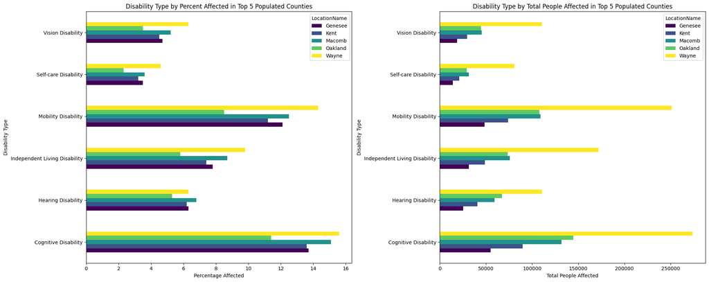

```python
# Identify the top 5 counties with the largest total population
top_counties = michigan_df.groupby("LocationName")["TotalPopulation"].sum().nlargest(5).index

# Filter the DataFrame for data related to the "Disability" category
top_county_data = michigan_df[
    (michigan_df["Category"] == "Disability") &  #Filter for Disability category
    (michigan_df["Short_Question_Text"] != "Any Disability") &  # Exclude "Any Disability"
    (michigan_df["LocationName"].isin(top_counties))  #Filter for top 5 counties
]

# Group the filtered data by 'Short_Question_Text' and 'LocationName',
# sum 'Data_Value' (percentage), and unstack the data to create a matrix format
disability_percentage = (
    top_county_data.groupby(["Short_Question_Text", "LocationName"])["Data_Value"]
    .sum()
    .unstack()  # Convert 'LocationName' to columns
    .fillna(0)  # Replace missing values with 0
)

# Similarly, group by 'Short_Question_Text' and 'LocationName',
# sum 'TotalPatients' (total people affected), and unstack the data
disability_total = (
    top_county_data.groupby(["Short_Question_Text", "LocationName"])["TotalPatients"]
    .sum()
    .unstack()  # Convert 'LocationName' to columns
    .fillna(0)  #replace missing values with 0
)

# Create a 1x2 grid of subplots for visualizing the data
fig, axes = plt.subplots(1, 2, figsize=(20, 8))

# First plot: Bar plot showing the percentage of people affected by different disabilities
disability_percentage.plot(kind="barh", colormap="viridis", ax=axes[0])
axes[0].set_xlabel("Percentage Affected")  # Label for the x-axis
axes[0].set_ylabel("Disability Type")  # Label for the y-axis
axes[0].set_title("Disability Type by Percent Affected in Top 5 Populated Counties")  # Title for the plot

# Second plot: Bar plot showing the total number of people affected by different disabilities
disability_total.plot(kind="barh", colormap="viridis", ax=axes[1])
axes[1].set_xlabel("Total People Affected")  # Label for the x-axis
axes[1].set_ylabel("Disability Type")  # Label for the y-axis
axes[1].set_title("Disability Type by Total People Affected in Top 5 Populated Counties")  # title for the plot

# Adjust the layout to prevent overlap of titles and labels
plt.tight_layout()

# Display the plots
plt.show()
```

We can infer the following:

- **Percentage of People Affected**: The first chart, showing the percentage of the population affected by different disabilities, reveals that **mobility disabilities** and **cognitive disabilities** are the most common conditions, with significant proportions of the population in these counties affected. Wayne County has the highest percentage, while Oakland County has the lowest percentage of individuals affected.
- **Total Number of People Affected**: The second chart, displaying the total number of people affected by disabilities, highlights counties with larger populations, which somewhat skews the results. For example, although **mobility disabilities** affect a significant percentage of people, this chart doesn't account for population size. Larger counties with higher populations, like Wayne County, show significantly higher numbers of people affected, while other counties with smaller populations show lower totals. This can potentially mislead our understanding of the true disability burden across the state.

Therefore, percentage chart is a more **reliable and insightful** method for analyzing the prevalence of disabilities, especially when comparing counties of varying sizes. The total number of affected individuals can be misleading in areas with larger populations, making percentages a more accurate way to understand how widespread each disability is across different regions in Michigan. We can make this visualization even clearer to read using a **100% stacked bar chart**.

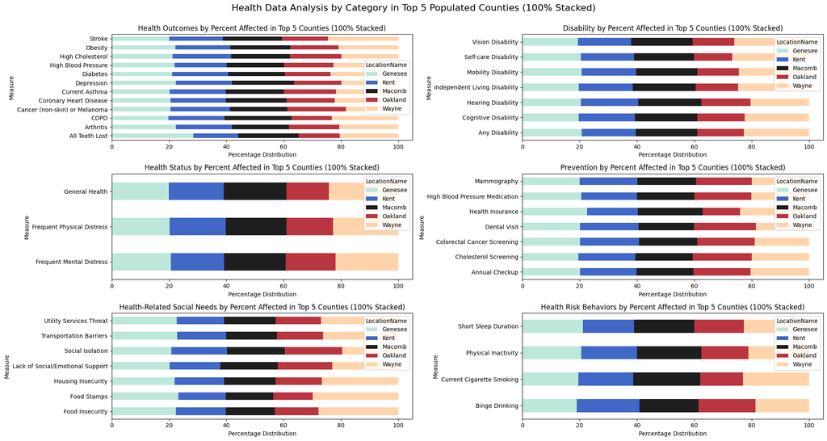

```python
# Create a 3x2 grid of subplots for visualizing different health categories
fig, axes = plt.subplots(3, 2, figsize=(20, 12))  # Define figure size
fig.suptitle("Health Data Analysis by Category in Top 5 Populated Counties (100% Stacked)", fontsize=16)
# Set the overall title for the figure

# Flatten the 3x2 axes array into a 1D array for easier iteration
axes = axes.flatten()

# Loop through each category in the predefined list and create 100% stacked bar charts
for i, category in enumerate(categories):
    # Filter the dataset to include only data for the selected category and top 5 populated counties
    category_data = michigan_df[
        (michigan_df["Category"] == category) &  # Select specific health category
        (michigan_df["LocationName"].isin(top_counties))  # Restrict to top 5 counties
    ]

    # Group by 'Short_Question_Text' and 'LocationName', summing up 'Data_Value' (percentage data)
    category_grouped = (
        category_data.groupby(["Short_Question_Text", "LocationName"])["Data_Value"]
        .sum()
        .unstack()  # Convert 'LocationName' values into columns
        .fillna(0)  # Replace NaN values with 0
    )

    # Convert data to percentages to create a 100% stacked bar chart
    category_grouped = category_grouped.div(category_grouped.sum(axis=1), axis=0) * 100

    # Plot the 100% stacked horizontal bar chart
    category_grouped.plot(kind="barh", stacked=True, colormap="icefire", ax=axes[i])

    # Set axis labels and titles
    axes[i].set_xlabel("Percentage Distribution")  # X-axis label
    axes[i].set_ylabel("Measure")  # Y-axis label
    axes[i].set_title(f"{category} by Percent Affected in Top 5 Counties (100% Stacked)")  # Set title

# Adjust the layout to prevent overlap of elements
plt.tight_layout(rect=[0, 0.1, 1, 0.98])

# Display the figure
plt.show()
```

### Census ACS Poverty/ Income Data (2022) Merge

We are now going to pull poverty-related data from the **U.S. Census Bureau's ACS API** for all counties in the 2022 ACS 5-Year dataset.

```python
# Load the CSV file
mapping = pd.read_csv(os.path.join(data_dir, "acs_poverty_md.csv"))

# Extract the column names for the API request
columns = mapping["Column Name"].tolist()

# Construct the API URL
base_url = "https://api.census.gov/data/2022/acs/acs5/subject"
params = ",".join(columns)
query_url = f"{base_url}?get={params}&for=county:*"

# Call the API
response = requests.get(query_url)
if response.status_code != 200:
    print(f"Error: {response.status_code}, {response.text}")
else:
    data = response.json()

    # Convert response to DataFrame
    census_df = pd.DataFrame(data[1:], columns=data[0])

    # Create a mapping from "Column Name" to "Label"
    column_mapping = dict(zip(mapping["Column Name"], mapping["Label"]))

    # Rename columns in census_df
    census_df.rename(columns=column_mapping, inplace=True)

    # Replace -999999999 values with 0
    census_df.replace("-999999999", "0", inplace=True)
    census_df.replace("-888888888", "0", inplace=True)
    census_df.replace("-666666666.0", "0", inplace=True)

    # Save to CSV
    census_df.to_csv(os.path.join(data_dir, "poverty_census_data.csv"), index=False)
    print("Data saved as poverty_census_data.csv")
```

```
Data saved as poverty_census_data.csv
```

Let's display the first few rows of the dataset to gain an initial understanding of its structure and contents.

```python
census_df.head()
```

|  | Geography | Geographic Area Name | Total | T_ Male | T_ Female | T_ African American | T_ American Indian/Alaska Native | T_ Asian | T_ Hawaiian/ Pacific Islander | T_ Two or more races | ... | BP_ Hispanic or Latino% | BP_ White% | T_Households | Households<$10k | Households>$200k | Median income | Mean income | BP_ Total% | state | county |
| --- | --- | --- | --- | --- | --- | --- | --- | --- | --- | --- | --- | --- | --- | --- | --- | --- | --- | --- | --- | --- | --- |
| 0 | 0500000US01001 | Autauga County, Alabama | 58291 | 28287 | 30004 | 11358 | 59 | 658 | 0 | 2473 | ... | 14.3 | 9.5 | 22308 | 4.4 | 7.4 | 68315 | 90372 | 11.4 | 01 | 001 |
| 1 | 0500000US01003 | Baldwin County, Alabama | 229539 | 111484 | 118055 | 18560 | 745 | 2046 | 31 | 10408 | ... | 27.6 | 7.7 | 90802 | 4.5 | 9.1 | 71039 | 96027 | 10.2 | 01 | 003 |
| 2 | 0500000US01005 | Barbour County, Alabama | 21851 | 10122 | 11729 | 10134 | 23 | 122 | 3 | 503 | ... | 62.2 | 9.7 | 9016 | 10.2 | 3.8 | 39712 | 60128 | 24.2 | 01 | 005 |
| 3 | 0500000US01007 | Bibb County, Alabama | 20836 | 10607 | 10229 | 3856 | 21 | 69 | 0 | 553 | ... | 32.7 | 15.3 | 7216 | 7.6 | 3.5 | 50669 | 65131 | 20.6 | 01 | 007 |
| 4 | 0500000US01009 | Blount County, Alabama | 58399 | 29527 | 28872 | 608 | 227 | 100 | 117 | 2083 | ... | 32.8 | 12.3 | 21626 | 6.7 | 4.9 | 57440 | 75954 | 14.2 | 01 | 009 |

5 rows × 29 columns

The **Geographic Area Name** column contains both the **county and state names**, which are essential for merging our dataset with the CDC's PLACES dataset. We need to extract both columns to merge the datasets accurately. We will also check the datatypes of the columns to ensure they are all easy to use for visualization/ manipulation.

```python
# Split 'Geographic Area Name' into State and County
census_df[['County', 'State']] = census_df['Geographic Area Name'].str.split(',', expand=True)

# Strip extra spaces
census_df['County'] = census_df['County'].str.strip().str.split().str[0]
census_df['State'] = census_df['State'].str.strip()

#Display the result
census_df.head()
```

|  | Geography | Geographic Area Name | Total | T_ Male | T_ Female | T_ African American | T_ American Indian/Alaska Native | T_ Asian | T_ Hawaiian/ Pacific Islander | T_ Two or more races | ... | T_Households | Households<$10k | Households>$200k | Median income | Mean income | BP_ Total% | state | county | County | State |
| --- | --- | --- | --- | --- | --- | --- | --- | --- | --- | --- | --- | --- | --- | --- | --- | --- | --- | --- | --- | --- | --- |
| 0 | 0500000US01001 | Autauga County, Alabama | 58291 | 28287 | 30004 | 11358 | 59 | 658 | 0 | 2473 | ... | 22308 | 4.4 | 7.4 | 68315 | 90372 | 11.4 | 01 | 001 | Autauga | Alabama |
| 1 | 0500000US01003 | Baldwin County, Alabama | 229539 | 111484 | 118055 | 18560 | 745 | 2046 | 31 | 10408 | ... | 90802 | 4.5 | 9.1 | 71039 | 96027 | 10.2 | 01 | 003 | Baldwin | Alabama |
| 2 | 0500000US01005 | Barbour County, Alabama | 21851 | 10122 | 11729 | 10134 | 23 | 122 | 3 | 503 | ... | 9016 | 10.2 | 3.8 | 39712 | 60128 | 24.2 | 01 | 005 | Barbour | Alabama |
| 3 | 0500000US01007 | Bibb County, Alabama | 20836 | 10607 | 10229 | 3856 | 21 | 69 | 0 | 553 | ... | 7216 | 7.6 | 3.5 | 50669 | 65131 | 20.6 | 01 | 007 | Bibb | Alabama |
| 4 | 0500000US01009 | Blount County, Alabama | 58399 | 29527 | 28872 | 608 | 227 | 100 | 117 | 2083 | ... | 21626 | 6.7 | 4.9 | 57440 | 75954 | 14.2 | 01 | 009 | Blount | Alabama |

5 rows × 31 columns

```python
# Display the data types of each column
census_df.dtypes
```

```
Geography                           object
Geographic Area Name                object
Total                               object
T_ Male                             object
T_ Female                           object
T_ African American                 object
T_ American Indian/Alaska Native    object
T_ Asian                            object
T_ Hawaiian/ Pacific Islander       object
T_ Two or more races                object
T_ Other race                       object
T_ Hispanic or Latino               object
T_ White                            object
BP_Total                            object
BP_ Male                            object
BP_ Female                          object
BP_ African American%               object
BP_ Asian%                          object
BP_ Two or more races%              object
BP_ Hispanic or Latino%             object
BP_ White%                          object
T_Households                        object
Households<$10k                     object
Households>$200k                    object
Median income                       object
Mean income                         object
BP_ Total%                          object
state                               object
county                              object
County                              object
State                               object
dtype: object
```

We can see that all the numerical columns are stored as objects in the Census ACS dataset. Therefore, we need to convert these columns from object to `int64` or `float64` for proper numerical analysis.

```python
# Extract the list of column labels from the 'Label' column in the mapping DataFrame.
label = mapping["Label"].tolist()

# Iterate through each column name in the extracted label list.
for column in label:
    # Check if the column is one of the specified columns that should be converted to float64.
    if column in ['Households<$10k', 'Households>$200k', 'BP_ Total%', 'BP_ African American%', 'BP_ American Indian/ Alaska Native%', 'BP_ Asian%', 'BP_ Hawaiian/ Pacific Islander%', 'BP_ Two or more races%', 'BP_ Other race%', 'BP_ Hispanic or Latino%', 'BP_ White%']:
        census_df[column] = census_df[column].astype('float64')  # Convert column to float64 type.

    # If the column is not 'Geography' or 'Geographic Area Name', convert it to int64.
    elif column not in ['Geography', 'Geographic Area Name']:
        census_df[column] = census_df[column].astype('int64')  # Convert column to int64 type.
```

```python
census_df.dtypes # Verify if the data type conversions were applied correctly.
```

```
Geography                            object
Geographic Area Name                 object
Total                                 int64
T_ Male                               int64
T_ Female                             int64
T_ African American                   int64
T_ American Indian/Alaska Native      int64
T_ Asian                              int64
T_ Hawaiian/ Pacific Islander         int64
T_ Two or more races                  int64
T_ Other race                         int64
T_ Hispanic or Latino                 int64
T_ White                              int64
BP_Total                              int64
BP_ Male                              int64
BP_ Female                            int64
BP_ African American%               float64
BP_ Asian%                          float64
BP_ Two or more races%              float64
BP_ Hispanic or Latino%             float64
BP_ White%                          float64
T_Households                          int64
Households<$10k                     float64
Households>$200k                    float64
Median income                         int64
Mean income                           int64
BP_ Total%                          float64
state                                object
county                               object
County                               object
State                                object
dtype: object
```

Now, let's merge the 'census_df' DataFrame with the 'health_df' DataFrame.

```python
# Merge datasets on State and County/LocationName
combined_df = census_df.merge(health_df, left_on=["State", "County"], right_on=["StateDesc", "LocationName"], how="inner")

# Display merged dataset
combined_df.head()
```

|  | Geography | Geographic Area Name | Total | T_ Male | T_ Female | T_ African American | T_ American Indian/Alaska Native | T_ Asian | T_ Hawaiian/ Pacific Islander | T_ Two or more races | ... | Data_Value_Type | Data_Value | TotalPopulation | TotalPop18plus | LocationID | CategoryID | MeasureId | Short_Question_Text | TotalPatients | TotalPatients18plus |
| --- | --- | --- | --- | --- | --- | --- | --- | --- | --- | --- | --- | --- | --- | --- | --- | --- | --- | --- | --- | --- | --- |
| 0 | 0500000US01001 | Autauga County, Alabama | 58291 | 28287 | 30004 | 11358 | 59 | 658 | 0 | 2473 | ... | Age-adjusted prevalence | 14.10 | 59759 | 45878 | 1001 | DISABLT | COGNITION | Cognitive Disability | 8426 | 6468 |
| 1 | 0500000US01001 | Autauga County, Alabama | 58291 | 28287 | 30004 | 11358 | 59 | 658 | 0 | 2473 | ... | Age-adjusted prevalence | 31.10 | 59759 | 45878 | 1001 | DISABLT | DISABILITY | Any Disability | 18585 | 14268 |
| 2 | 0500000US01001 | Autauga County, Alabama | 58291 | 28287 | 30004 | 11358 | 59 | 658 | 0 | 2473 | ... | Age-adjusted prevalence | 37.70 | 59759 | 45878 | 1001 | RISKBEH | SLEEP | Short Sleep Duration | 22529 | 17296 |
| 3 | 0500000US01001 | Autauga County, Alabama | 58291 | 28287 | 30004 | 11358 | 59 | 658 | 0 | 2473 | ... | Age-adjusted prevalence | 6.40 | 59759 | 45878 | 1001 | DISABLT | HEARING | Hearing Disability | 3824 | 2936 |
| 4 | 0500000US01001 | Autauga County, Alabama | 58291 | 28287 | 30004 | 11358 | 59 | 658 | 0 | 2473 | ... | Age-adjusted prevalence | 12.00 | 59759 | 45878 | 1001 | HLTHOUT | TEETHLOST | All Teeth Lost | 7171 | 5505 |

5 rows × 48 columns

Let's examine all the columns in the dataset to determine if we need to drop any unnecessary columns or rename them for clarity and consistency.

```python
combined_df.columns # Display the column names of the merged 'combined_df' DataFrame.
```

```
Index(['Geography', 'Geographic Area Name', 'Total', 'T_ Male', 'T_ Female',
       'T_ African American', 'T_ American Indian/Alaska Native', 'T_ Asian',
       'T_ Hawaiian/ Pacific Islander', 'T_ Two or more races',
       'T_ Other race', 'T_ Hispanic or Latino', 'T_ White', 'BP_Total',
       'BP_ Male', 'BP_ Female', 'BP_ African American%', 'BP_ Asian%',
       'BP_ Two or more races%', 'BP_ Hispanic or Latino%', 'BP_ White%',
       'T_Households', 'Households<$10k', 'Households>$200k', 'Median income',
       'Mean income', 'BP_ Total%', 'state', 'county', 'County', 'State',
       'Year', 'StateAbbr', 'StateDesc', 'LocationName', 'Category', 'Measure',
       'Data_Value_Unit', 'Data_Value_Type', 'Data_Value', 'TotalPopulation',
       'TotalPop18plus', 'LocationID', 'CategoryID', 'MeasureId',
       'Short_Question_Text', 'TotalPatients', 'TotalPatients18plus'],
      dtype='object')
```

Some columns in the dataset serve as ID columns, and others are duplicated after merging the data. These columns can be removed to streamline the dataset and avoid redundancy. `Data_Value` and `Short_Question_Text` have pretty ambiguous names. We will also rename these columns for clarity and ease of use. `

```python
# Define a list of columns to exclude from the 'combined_df' DataFrame.
exclude_columns = ['Geography', 'Geographic Area Name', 'state', 'county', 'Year', 'Data_Value_Unit', 'Data_Value_Type', 'LocationID', 'CategoryID', 'MeasureId', 'StateDesc', 'LocationName', 'Measure']

# Drop the specified columns from 'combined_df' and create a new DataFrame 'combined_df_dropped'.
combined_df_dropped = combined_df.drop(exclude_columns, axis=1)
```

```python
# Rename columns in the 'combined_df_dropped' dataFrame for clarity.
combined_df_clean = combined_df_dropped.rename(columns={'Data_Value': 'Pop_Percent', 'Short_Question_Text': 'Health_Measure'})
```

```python
# Save the cleaned combined dataframe to a CSV file without including the index column for future assignments
combined_df_clean.to_csv(os.path.join(data_dir, "complete_data.csv"), index=False)
```

Now, let's filter the DataFrame to focus on the data for Michigan, similar to what we did for the previous dataset.

```python
# Filter the 'combined_df_clean' DataFrame to include only rows where the 'State' column is "Michigan".
# Store the result in 'mi_df' and display the first few rows to verify the data.
mi_df = combined_df_clean[combined_df_clean['State'] == "Michigan"]
mi_df.head()
```

|  | Total | T_ Male | T_ Female | T_ African American | T_ American Indian/Alaska Native | T_ Asian | T_ Hawaiian/ Pacific Islander | T_ Two or more races | T_ Other race | T_ Hispanic or Latino | ... | County | State | StateAbbr | Category | Pop_Percent | TotalPopulation | TotalPop18plus | Health_Measure | TotalPatients | TotalPatients18plus |
| --- | --- | --- | --- | --- | --- | --- | --- | --- | --- | --- | --- | --- | --- | --- | --- | --- | --- | --- | --- | --- | --- |
| 43387 | 10128 | 5132 | 4996 | 33 | 40 | 32 | 2 | 349 | 70 | 186 | ... | Alcona | Michigan | MI | Health Outcomes | 8.90 | 10417 | 9084 | All Teeth Lost | 927 | 808 |
| 43388 | 10128 | 5132 | 4996 | 33 | 40 | 32 | 2 | 349 | 70 | 186 | ... | Alcona | Michigan | MI | Health Risk Behaviors | 21.10 | 10417 | 9084 | Current Cigarette Smoking | 2197 | 1916 |
| 43389 | 10128 | 5132 | 4996 | 33 | 40 | 32 | 2 | 349 | 70 | 186 | ... | Alcona | Michigan | MI | Prevention | 60.40 | 10417 | 9084 | Colorectal Cancer Screening | 6291 | 5486 |
| 43390 | 10128 | 5132 | 4996 | 33 | 40 | 32 | 2 | 349 | 70 | 186 | ... | Alcona | Michigan | MI | Disability | 31.70 | 10417 | 9084 | Any Disability | 3302 | 2879 |
| 43391 | 10128 | 5132 | 4996 | 33 | 40 | 32 | 2 | 349 | 70 | 186 | ... | Alcona | Michigan | MI | Prevention | 76.80 | 10417 | 9084 | Mammography | 8000 | 6976 |

5 rows × 35 columns

```python
mi_df.describe()
```

|  | Total | T_ Male | T_ Female | T_ African American | T_ American Indian/Alaska Native | T_ Asian | T_ Hawaiian/ Pacific Islander | T_ Two or more races | T_ Other race | T_ Hispanic or Latino | ... | Households<$10k | Households>$200k | Median income | Mean income | BP_ Total% | Pop_Percent | TotalPopulation | TotalPop18plus | TotalPatients | TotalPatients18plus |
| --- | --- | --- | --- | --- | --- | --- | --- | --- | --- | --- | --- | --- | --- | --- | --- | --- | --- | --- | --- | --- | --- |
| count | 3120.00 | 3120.00 | 3120.00 | 3120.00 | 3120.00 | 3120.00 | 3120.00 | 3120.00 | 3120.00 | 3120.00 | ... | 3120.00 | 3120.00 | 3120.00 | 3120.00 | 3120.00 | 3120.00 | 3120.00 | 3120.00 | 3120.00 | 3120.00 |
| mean | 121093.33 | 59891.65 | 61201.68 | 16762.72 | 544.27 | 4063.29 | 33.46 | 6551.09 | 1915.46 | 6607.00 | ... | 4.81 | 5.06 | 61476.36 | 80080.79 | 13.26 | 24.41 | 123430.40 | 97466.38 | 29996.29 | 23672.87 |
| std | 266531.30 | 130310.66 | 136238.00 | 77675.37 | 901.78 | 14461.68 | 80.37 | 14772.52 | 5878.26 | 16528.74 | ... | 1.38 | 3.00 | 10810.73 | 14517.29 | 3.58 | 21.58 | 267338.60 | 208317.13 | 92545.27 | 72151.51 |
| min | 2084.00 | 1089.00 | 995.00 | 0.00 | 8.00 | 0.00 | 0.00 | 67.00 | 0.00 | 28.00 | ... | 1.80 | 1.50 | 45946.00 | 58223.00 | 4.90 | 2.20 | 2180.00 | 1834.00 | 54.00 | 45.00 |
| 25% | 22213.00 | 11043.00 | 11008.00 | 104.00 | 97.00 | 88.00 | 0.00 | 752.00 | 92.00 | 444.00 | ... | 4.00 | 3.00 | 54074.00 | 70516.00 | 10.70 | 8.90 | 22870.00 | 18122.00 | 2683.75 | 2196.50 |
| 50% | 33723.00 | 17187.50 | 16657.50 | 259.50 | 216.00 | 154.00 | 10.00 | 1384.00 | 275.00 | 955.50 | ... | 4.55 | 4.05 | 59245.00 | 77075.50 | 13.60 | 16.30 | 36517.00 | 29739.50 | 6923.00 | 5579.00 |
| 75% | 94326.00 | 46904.00 | 47422.00 | 1264.00 | 615.00 | 840.00 | 23.00 | 5103.00 | 996.00 | 5196.00 | ... | 5.80 | 6.40 | 67905.00 | 87433.00 | 15.70 | 31.10 | 98567.00 | 78539.00 | 19788.75 | 15955.25 |
| max | 1762492.00 | 854630.00 | 907862.00 | 662134.00 | 5466.00 | 102546.00 | 449.00 | 91269.00 | 45130.00 | 111990.00 | ... | 9.80 | 16.50 | 96135.00 | 126488.00 | 23.60 | 87.90 | 1757043.00 | 1345110.00 | 1488215.00 | 1139308.00 |

8 rows × 30 columns

Since we want to keep duplicate entries from distorting the results, let's drop duplicate counties and keep only the first occurrence. This will ensure that each county is represented once in the dataset.

```python
# Drop duplicate counties, keeping only the first occurrence
unique_mi_df = mi_df.drop_duplicates(subset=['County'])
```

Next, we will generate a **histogram** and **box plot** so that we can visually explore the distribution and spread of median income across Michigan counties. The histogram will help us understand the frequency of different income ranges, while the box plot will allow us to assess the spread, identify potential outliers, and determine the central tendency of the income data. By comparing both plots, we can gain insights into income inequality and regional disparities in Michigan's counties.

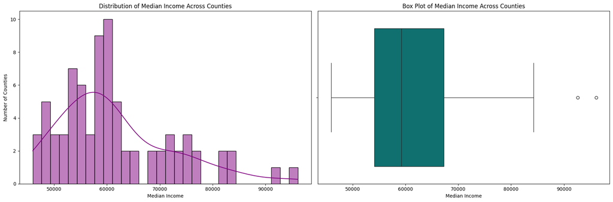

```python
# Set figure size for both plots
fig, axes = plt.subplots(1, 2, figsize=(18, 6))

# Histogram: Distribution of Median Income
sns.histplot(unique_mi_df['Median income'], bins=30, kde=True, ax=axes[0], color='purple')
axes[0].set_title("Distribution of Median Income Across Counties")
axes[0].set_xlabel("Median Income")
axes[0].set_ylabel("Number of Counties")

# Box Plot: Spread of Median Income
sns.boxplot(x=unique_mi_df['Median income'], ax=axes[1], color='teal')
axes[1].set_title("Box Plot of Median Income Across Counties")
axes[1].set_xlabel("Median Income")

# Adjust layout and show plots
plt.tight_layout()
plt.show()
```

We can infer the following:

The histogram reveals that most counties in Michigan have a median income ranging from **$55k to $70k**. However, there are some extreme tails and outliers--a few counties show median incomes **below $50k** and others above **$90k**. This might suggest that while the majority of counties fall within the middle-income range, there are certain areas with significantly lower or higher incomes which could contribute to regional income disparities.

The box plot further confirms these trends by highlighting the spread of values.

Next, we will try analyzing the differences between high and low poverty areas. We can filter the `mi_df` dataframe to identify both the highest and lowest poverty counties. By doing this, we might gain some insight into how poverty rates correlate with other socioeconomic factors such as median income, population size, and healthcare outcomes. While median income is a great metric to calculate this, the percentage of people below poverty level (poverty rates) can give insights for counties with high income disparities.

```python
# Find the highest median income
highest_poverty = mi_df['BP_ Total%'].max()

# Use np.where to filter the dataset for the highest-earning county
highest_poverty_df = mi_df[np.where(mi_df['BP_ Total%'] == highest_poverty, True, False)]

highest_poverty_df[['County', 'TotalPopulation', 'BP_ Total%', 'Median income']].head(1)
```

|  | County | TotalPopulation | BP_ Total% | Median income |
| --- | --- | --- | --- | --- |
| 44787 | Isabella | 64447 | 23.60 | 52638 |

```python
# Find the lowest median income
lowest_poverty = mi_df['BP_ Total%'].min()

# Use np.where to filter the dataset for the lowest-earning county
lowest_poverty_df = mi_df[np.where(mi_df['BP_ Total%'] == lowest_poverty, True, False)]

lowest_poverty_df[['County', 'TotalPopulation', 'BP_ Total%', 'Median income']].head(1)
```

|  | County | TotalPopulation | BP_ Total% | Median income |
| --- | --- | --- | --- | --- |
| 45187 | Livingston | 196161 | 4.90 | 96135 |

From the output, we can see that

- The county with the highest poverty rates is **Isabella County** and the county with the lowest poverty rates is **Livingston County**.
- Livingston County has a lower poverty rate of 4.90%, indicating a relatively affluent population, and Isabella County has a higher poverty rate of 23.60% indicating that a larger portion of the population is economically disadvantaged.

Finally, let's display **health data by category** for both the **highest and lowest poverty counties**, which will allow us to compare the health metrics across various categories between high and low poverty areas and possibly give us some more insights into the health disparities between the two extreams.

```python
def plot_health_data_by_category(df):
        # Define the list of categories to filter the data by
    categories = [
        'Health Outcomes', 'Disability', 'Health Status', 'Prevention',
        'Health-Related Social Needs', 'Health Risk Behaviors'
    ]  # Select categories for analysis

    # Create a 2x3 grid of subplots to accommodate the six categories
    fig, axes = plt.subplots(3, 2, figsize=(18, 12))
    fig.suptitle("Health Data Analysis by Category", fontsize=16)

    # Flatten the axes array to make iteration easier
    axes = axes.flatten()

    # Loop through each category to create a bar chart for each
    for i, category in enumerate(categories):
        # Filter data for the current category, group by 'Health_Measure',
        # sum 'Pop_Percent', and sort values in descending order
        category_data = (
            df[df['Category'] == category]
            .groupby('Health_Measure')['Pop_Percent']
            .sum()
            .sort_values(ascending=False)
        )

        # Create a bar plot for the current category
        sns.barplot(x=category_data.values, y=category_data.index, palette="crest", ax=axes[i])

        # Set the x-axis label and format the x-axis tick labels to prevent scientific notation
        axes[i].set_xlabel("Percent of People Affected")
        axes[i].ticklabel_format(style='plain', axis='x')

        # Set the y-axis label and title for the subplot
        axes[i].set_ylabel(category)
        axes[i].set_title(f"{category} by Percent of People Affected")

    # Adjust the layout to prevent overlap of titles and labels
    plt.tight_layout(rect=[0, 0.1, 1, 0.98])

    # Display the plots
    plt.show()
```

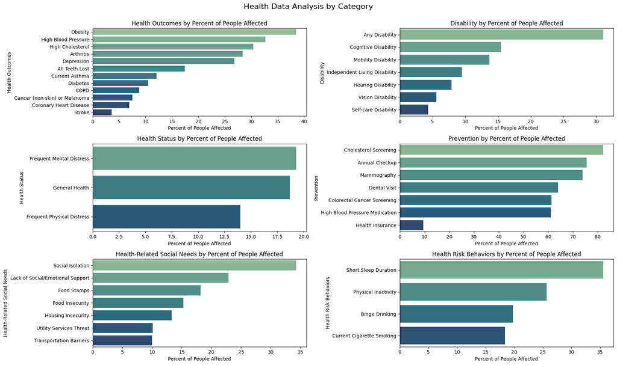

```python
plot_health_data_by_category(highest_poverty_df) # for Isabella
```

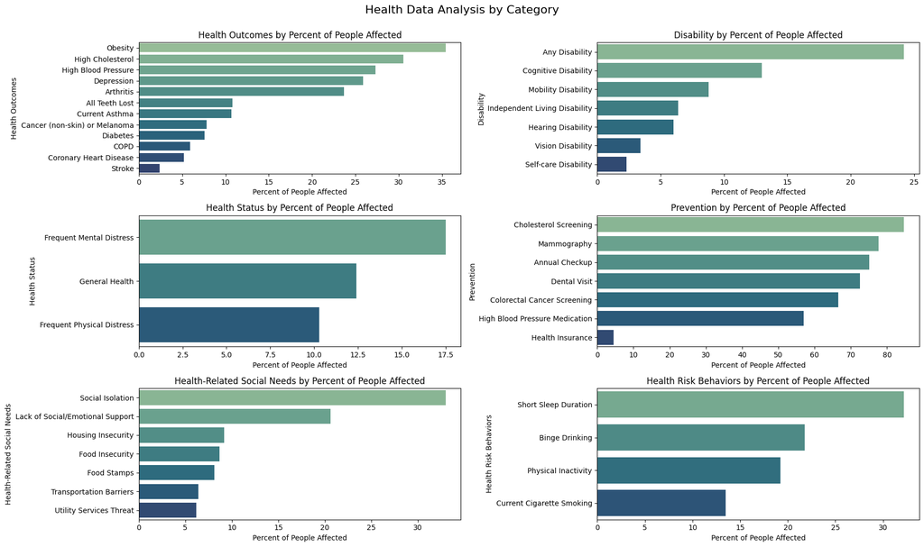

```python
plot_health_data_by_category(lowest_poverty_df) # for Livingston
```

We can see that in **Isabella County**, which has the highest poverty rate, the general health of the population appears to be poorer. People in this county are more likely to rely on health-related social services and face challenges such as food insecurity. Additionally, there is a greater prevalence of health risk behaviors in this county, likely as a result of the increased stress and economic hardships associated with higher poverty levels.

On the other hand, **Livingston County**, which has the lowest poverty rate, presents a different health challenge. Despite having fewer people living in poverty, the county shows a higher incidence of binge drinking, which is a significant health risk behavior.

## 🏁 Conclusion:

This first part of the project has revealed some valuable insights into the relationship between poverty rates and health outcomes. Our data manipulation serves as a starting point for a broader understanding of how various socioeconomic factors interact with health. From what we have seen, we think there is a potential to uncover even more patterns and connections.

Given more time, we could analyze trends within other states, not just Michigan. We can focus on that in Project Part 2!

## 🤖 Declaration of Gen AI:

We have used generative AI for

- Markdown beautification in the introduction.
- Editing our code comments to make them more professional in appearance, and
- Assisting in renaming columns in the **acs_poverty_md.csv** file from the ACS API metadata. For example, `Estimate!!Total!!Population for whom poverty status is determined!!SEX!!Male` to `T_ Male`, and so on.